# Workshop on Bayesian Workflow

26-27 November 2026

This notebook contains some of the material covered during the two-day *[Bayesian Workflow](https://avehtari.github.io/Bayesian-Workflow/)* workshop at Karolinska Institutet in late November 2026. It is intended for those who are relatively new to Bayesian statistics and the workflow.

The workshop was organized by Simon Steiger, Frida Smids, Paulina Sell and Younes Laalou.  
Find more events and information [on our website](https://learnbayes.se).

# Simulation and priors

The first exercise is to simulate a dataset that we can then use to build a statistical model.

## Simulating data

We’ll simulate data on air pollution (AP), chronic kidney disease (CKD), age, and systolic blood pressure (BP). The goal is not to make is super realistic, but if the variables and their relationships make a little bit of sense, it’s easier to think about.

[figure not shown]

Figure 1: Relationships between AP, CKD, age and BP

In our dataset, exposure to AP increases BP, while having CKD makes this effect stronger. With older age, the risk to develop CKD increases, and so does BP.

Let’s first set up the workspace.

```r
library(rethinking)
```

### Air pollution

We start by simulating the independent variables, meaning those that don’t have an arrow pointing at them. These are AP and age. We could imagine different air pollutants here, but we’ll go with a common one: fine particulate matter, PM<sub>2.5</sub>. Real air pollution measurements often follow a right-skewed shape with most values falling within a “commonly observed” range, but some places are much more polluted, so we have a heavy tail to the right. Distributions that give us something similar are gamma or log-normal.

```r
n <- 1000 # simulating 1000 individuals
AP <- rgamma(n, 8, 2)
# exp(log(10) + rnorm(n, 0, 0.3))

summary(AP)
```

```
   Min. 1st Qu.  Median    Mean 3rd Qu.    Max.
  1.077   2.928   3.804   3.956   4.806   8.924
```

### Age

Simulating age is very straightforward. We use the uniform distribution so that the whole range between 55 and 95 years is covered nicely.

```r
age <- round(runif(n, 55, 95))
summary(age)
```

```
   Min. 1st Qu.  Median    Mean 3rd Qu.    Max.
  55.00   66.00   76.00   75.28   85.00   95.00
```

### Chronic kidney disease

CKD is next and it depends on age. Older people have a higher risk to develop CKD.

[figure not shown]

Figure 2

This is why we first set the effect for age on CKD, so how much the risk to develop CKD increases with each year.

```r
b_age_CKD <- 0.3
```

I set it to 0.3 here, which is definitely not evidence-based :’)

CKD status is binary, so we need to assign yes / no to everybody. And this assignment should be based on the age of each individual. Soo… ??

We first assign a *probability* to have CKD to everybody.

```r
prob_CKD <- inv_logit(-2.5 + ((age - mean(age)) * b_age_CKD))
prob_CKD[1:5]
```

```
[1] 0.001131476 0.039806676 0.968228548 0.120988764 0.788665485
```

Above, we center the age variable by subtracting the mean from everybody’s age, then we multiply by the effect (`b_age_CKD`) from above. `inv_logit` transforms everything to be between 0 and 1 (which we need here, because we want *probabilities*) and the -2.5 means “not likely” in log-odds space. So the “baseline risk” to have CKD is quite low. (Btw, we set -2.5 by just trying different values and looking at the results which feels weird but it’s okay!)

The next step is more straightforward again, we just sample from a Bernoulli distribution, using the individual *probabilities* to have CKD.

```r
CKD <- rbern(n, prob_CKD) + 1
table(CKD)
```

```
CKD
  1   2
710 290
```

By `+ 1` we make the `[0, 1]` variable a `[1, 2]` variable, with `1` being no CKD and `2` being CKD. This is necessary if we don’t want to estimate an offset between the two, but the effects in both CKD groups. We’ll see this in the model code later.

### Systolic blood pressure

Now we want to add a blood pressure value for each person in the sample. We first set the effects of age, AP and CKD status on BP as well as noise (`sigma_BP`) for BP.

```r
a_BP <- c(110, 120) # direct effect of CKD on BP
b_age_BP <- 0.27
b_AP_BP <- c(1.3, 2.2) # interaction
sigma_BP <- 5
```

`b_AP_BP` creates the interaction: the effect of air pollution on BP is 1.3 for people without CKD and 2.2 for people with CKD.

```r
BP <- round(
  rnorm(
    n,
    mean = a_BP[CKD] +
      b_age_BP * age +
      b_AP_BP[CKD] * AP,
    sd = sigma_BP
  ),
  1
)
```

The last thing we’ll add is an ID variable.

```r
id <- 1:n
```

Now we add everything to a dataframe and save it.

```r
data <- data.frame(
  id,
  age,
  BP,
  CKD,
  AP
)

write.csv(data, "data/data.csv", row.names = FALSE)
```

## Plotting the data

Let’s plot the data.

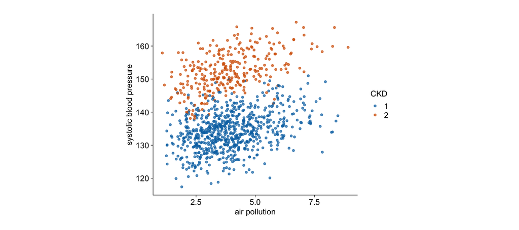

```r
library(tidyplots)

data <- read.csv("data/data.csv")
data$CKD <- as.factor(data$CKD)

data |>
  tidyplot(x = AP, y = BP, color = CKD) |>
  add_data_points(alpha = 0.7) |>
  # add_curve_fit(method = "lm") |>
  adjust_y_axis_title("systolic blood pressure") |>
  adjust_x_axis_title("air pollution") |>
  adjust_size(width = 90, height = 80) |>
  adjust_font(fontsize = 10)
```

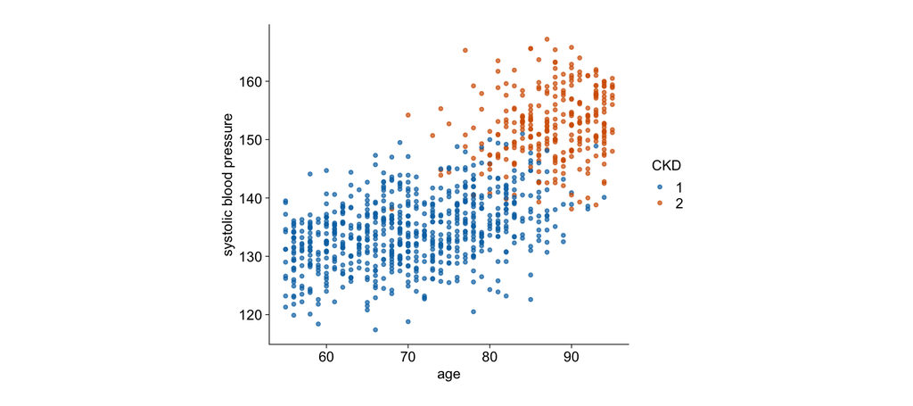

```r
data |>
  tidyplot(x = age, y = BP, color = CKD) |>
  add_data_points(alpha = 0.7) |>
  # add_curve_fit(method = "lm") |>
  adjust_y_axis_title("systolic blood pressure") |>
  adjust_x_axis_title("age") |>
  adjust_size(width = 90, height = 80) |>
  adjust_font(fontsize = 10)
```

Great! Now we can move on to modeling :)

# Parameter estimation

## Statistical model

This is the full statistical model. I’ll explain the parameters below, but take a second and see if you can find something familiar in there from the simulation steps.

**Likelihood**

- $\text{BP}_i \sim \mathcal{N}(\mu_i, \sigma)$: We assume each person’s observed blood pressure comes from a normal distribution. Its centre is $\mu_i$, the *expected* BP for person $i$. $\sigma$ is the spread, so how far individual values spread around that expectation.

## Prior prediction

Let’s check if our priors make sense. We draw 20 values from the priors for $\alpha$ and $\beta_{\text{AP}}$. Then we plot all of these lines. This plot tells us which relationships between AP and BP the prior “thinks” are possible.

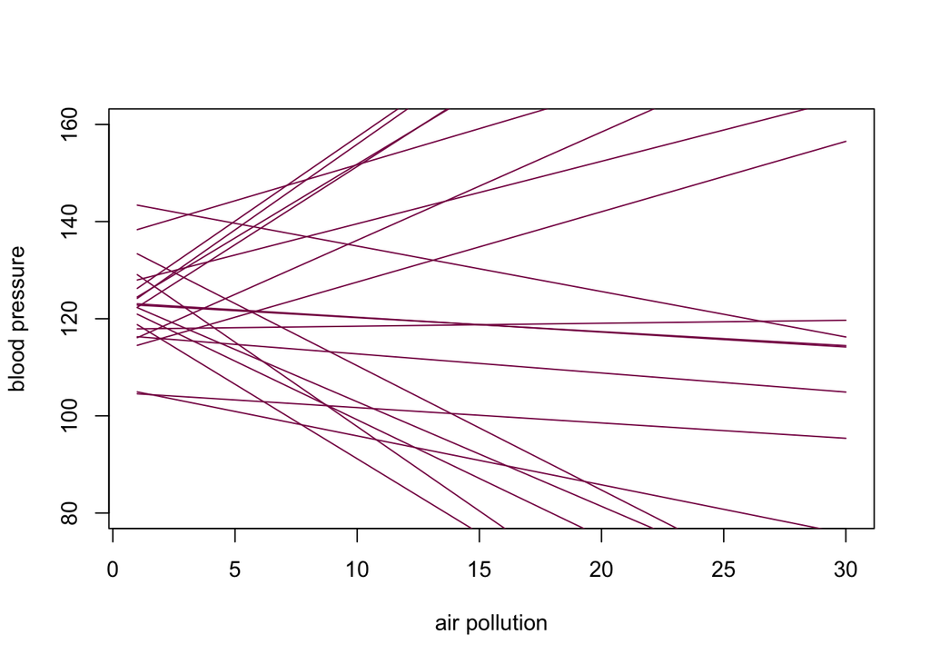

```r
n <- 20
sim_a <- rnorm(n, 120, 10)
sim_b_AP <- rnorm(n, 0, 2)

AP_seq <- seq(from = 1, to = 30, length.out = 30)

plot(
  NULL,
  xlim = c(1, 30),
  ylim = c(80, 160),
  xlab = "air pollution",
  ylab = "blood pressure"
)
for (i in 1:n) {
  mu <- sim_a[i] + sim_b_AP[i] * AP_seq
  lines(AP_seq, mu, lwd = 1, col = "#870052")
}
```

Looks good!

Now we continue with age and blood pressure:

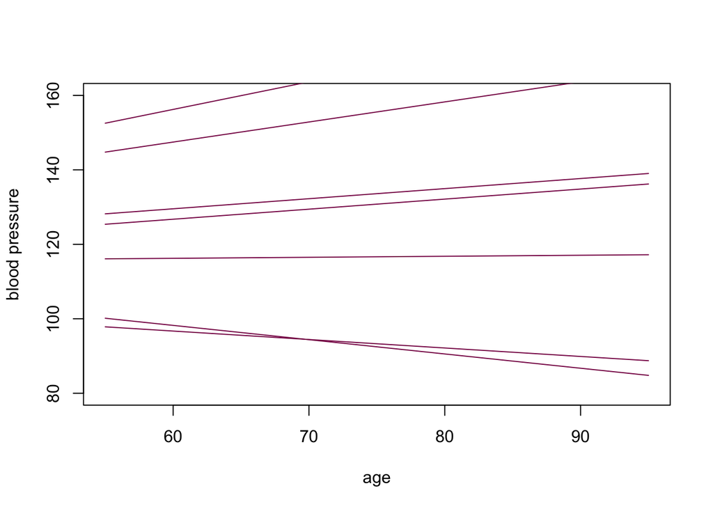

```r
n <- 20
sim_a <- rnorm(n, 120, 10)
sim_b_age <- rnorm(n, 0, 2)

age_seq <- seq(from = 55, to = 95, length.out = 40)

plot(
  NULL,
  xlim = c(55, 95),
  ylim = c(80, 160),
  xlab = "age",
  ylab = "blood pressure"
)
for (i in 1:n) {
  mu <- sim_a[i] + sim_b_age[i] * age_seq
  lines(age_seq, mu, lwd = 1, col = "#870052")
}
```

This is not ideal, but okay for our purpose, because we have enough data. We could have improved the prior for age by centering the variable, so that we set it for the *mean* age (as we did when assigning the probabilities to have CKD). Here, we instead set the prior for a newborn, which is a bit less intuitive and harder to do right.

## Fitting the model

Now we are ready to fit the model. Notice how similar the model code is to our simulation code and the statistical model! Once you have these things, it’s really easy to fill out the model.

```r
data <- as.list(read.csv("data/data.csv"))

m_AP_BP <- ulam(
  alist(
    BP ~ dnorm(mu, sigma),
    mu <- a[CKD] + b_AP_BP[CKD] * AP + b_age_BP * age,
    a[CKD] ~ dnorm(120, 10),
    b_AP_BP[CKD] ~ dnorm(0, 2),
    b_age_BP ~ dnorm(0, 2),
    sigma ~ dexp(1)
  ),
  data = data,
  chains = 4,
  iter = 1000
)
```

Let’s see whether the model recovered the parameters we set in the simulation!

```
a_BP       = 110, 120
b_AP_BP    = 1.3, 2.2
b_age_BP   = 0.27
sigma_BP   = 5
```

```r
precis(m_AP_BP, depth = 2)
```

```
                  mean         sd        5.5%       94.5%     rhat  ess_bulk
a[1]       111.9291188 1.53128243 109.4885374 114.3848773 1.004946  815.9514
a[2]       123.2279258 1.97338824 120.1173735 126.2356583 1.006218  811.4185
b_AP_BP[1]   1.3728100 0.13185394   1.1704541   1.5782363 1.004236 1516.8531
b_AP_BP[2]   2.0982907 0.19810181   1.7758859   2.4044250 1.002159 1457.8724
b_age_BP     0.2398596 0.02048416   0.2077476   0.2715244 1.004705  825.0164
sigma        4.9879741 0.11461257   4.8128774   5.1740435 1.001335 1638.3728
```

Isn’t that satisfying <:

# Model validation & visualization

Before we explore what we can do with these results, we should look at a few things to make sure the model worked fine. This is of course way more important when working with real data, because we obviously can’t just check if our model found the “real” effects.

## Identify issues in estimation

There are a few things we can easily check in every model. These give us hints on whether we can trust the model.

### Rhat

In the `precis` output above, the $\hat{R}$ value (`rhat`) indicates whether the four Markov chain Monte Carlo (MCMC) chains have converged, meaning if they agree with each other. A value of less than 1.01 is generally considered good.  
All of our $\hat{R}$ values are below 1.01, which is good! But of course, a good $\hat{R}$ value doesn’t mean that the model is right. The chains could converge on the same wrong answer.

### Effective Sample Size (ESS)

When the MCMC algorithm moves around the parameter space we want to learn about, each new step (or iteration) is dependent on the last one. This means that the samples we generate are somewhat correlated. The ESS value gives us an idea of how many *truly independent* samples would give us the same quality of information as the correlated samples. Let’s take one of our parameters, `b_age_BP` as an example. The ESS for the bulk of the posterior distribution is 825. This means that, in simple terms, our estimate is as good as 825 independent samples. This corresponds to 41% of our total samples, which is okay.

### Trace Plots

Now we’ll have a look at how the four chains moved around to explore the posteriors of the parameters.

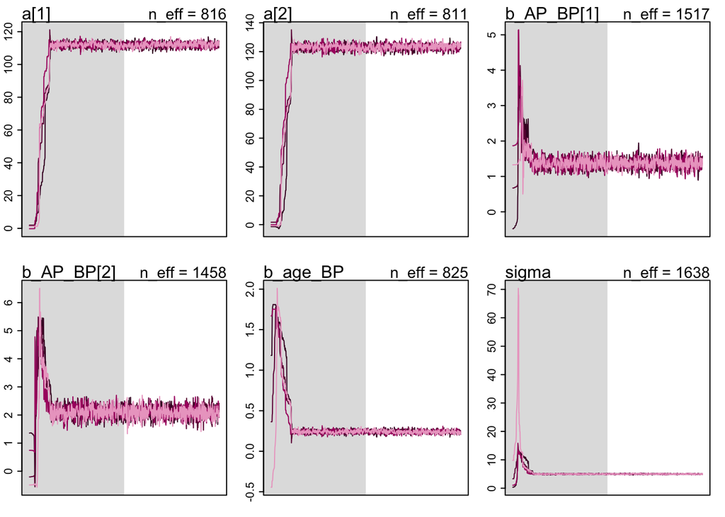

```r
old_par <- par(xaxt = "n")

traceplot(
  m_AP_BP,
  lwd = 1,
  col = c("#45032c", "#6f0344", "#aa166f", "#eca7c9")
)
```

```r
par(old_par)
```

But in order to judge whether the chains have converged or not, we should “zoom” into the second half of sampling.

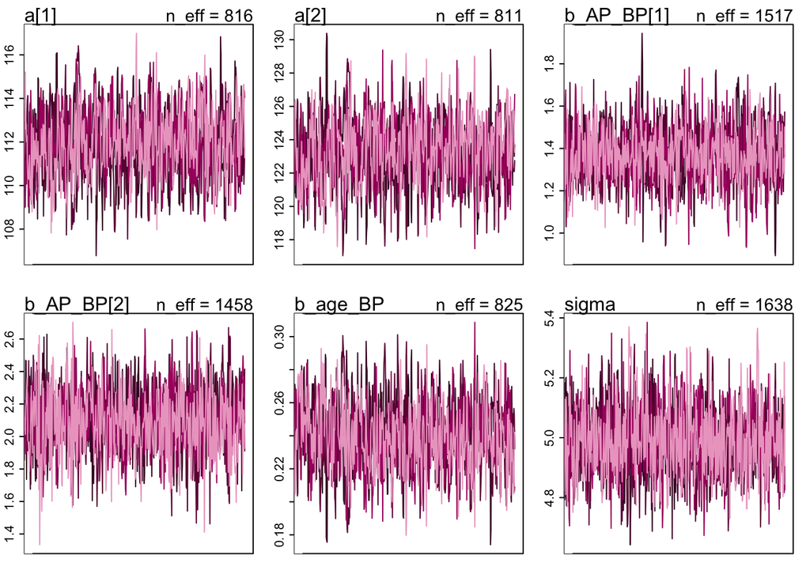

```r
old_par <- par(xaxt = "n")

traceplot(
  m_AP_BP,
  window = c(501, 1000),
  lwd = 1,
  col = c("#45032c", "#6f0344", "#aa166f", "#eca7c9"),
  bg = "white"
)
```

```r
par(old_par)
```

This looks like the chains agree with each other. If some of the chains would have been stuck in some region and you could distinguish them from one another, that would be a sign that something went wrong. You can see a few examples of bad looking traceplots [here](https://arviz-devs.github.io/EABM/Chapters/MCMC_diagnostics.html#trace-plots).

## Visualize the results

Now let’s visualize our results!

```r
age_value <- 55 # we plot the line for one age (otherwise we'd need another dimension)

post_samples <- extract.samples(m_AP_BP)

APseq <- seq(from = 1, to = 30, by = 0.5)

n_samples <- nrow(post_samples$a)
n_x <- length(APseq)
n_ckd <- 2

pred_bp <- array(dim = c(n_samples, n_ckd, n_x))

for (i in 1:n_samples) {
  for (j in 1:n_ckd) {
    pred_bp[i, j, ] <- post_samples$a[i, j] +
      post_samples$b_AP_BP[i, j] * APseq +
      post_samples$b_age_BP[i] * age_value
  }
}

summarise_draws <- function(pred, x_values, quantiles = c(0.1, 0.5, 0.9)) {
  pred_dims <- dim(pred)
  n_ckd <- pred_dims[2]
  out <- array(dim = c(length(quantiles), tail(pred_dims, 2)))

  for (i in seq_along(quantiles)) {
    for (j in 1:n_x) {
      for (k in 1:n_ckd) {
        draws_j <- pred[, k, j] # all posterior draws for AP value j
        out[i, k, j] <- quantile(draws_j, prob = quantiles[i])
      }
    }
  }

  out
}

bp_summary <- summarise_draws(pred_bp, APseq)
```

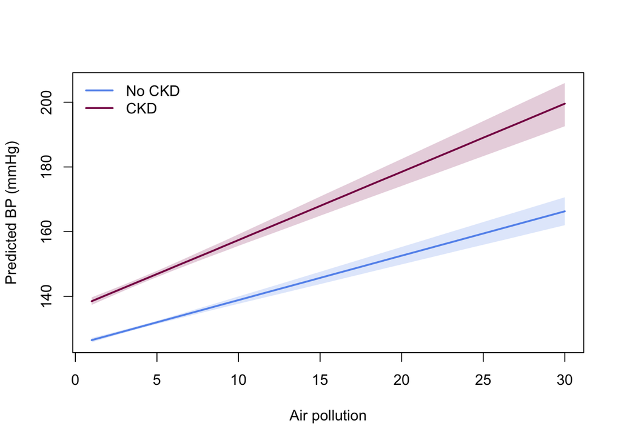

```r
plot(
  NULL,
  xlim = range(APseq),
  ylim = range(c(bp_summary[1, 1, ], bp_summary[3, 2, ])),
  xlab = "Air pollution",
  ylab = "Predicted BP (mmHg)"
)

color <- c("cornflowerblue", "#870052")

for (i in 1:n_ckd) {
  shade(
    rbind(bp_summary[1, i, ], bp_summary[3, i, ]),
    APseq,
    col = col.alpha(color[i], 0.2)
  )
  lines(APseq, bp_summary[2, i, ], col = color[i], lwd = 2)
}

legend(
  "topleft",
  legend = c("No CKD", "CKD"),
  col = c("cornflowerblue", "#870052"),
  lwd = 2,
  bty = "n"
)
```

# Postprocessing

## Downstream quantities

### Attributable cases of high BP (>130)

What if AP was 0 for everybody? What if AP was below 5 for everybody? What if we prevented all CKD?